# Classification iiiD

Keyon Hedayati

4/24/2022

```r
library(tidyverse)
library(caret)
```

```r
library(coefplot)
library(recipes)
df_all <- readr::read_csv("final_project_train.csv", col_names = TRUE)
dfiiiD <- df_all %>%
  mutate(outcome = factor(outcome,
                          levels = c("event", "non_event"))) %>%
  select(region, customer, starts_with('x'), outcome)

dfiiiD %>% glimpse()
```

```
## Rows: 677
## Columns: 36
## $ region   <chr> "XX", "XX", "XX", "XX", "XX", "XX", "XX", "XX", "XX", "XX", "…
## $ customer <chr> "B", "B", "B", "B", "B", "B", "B", "B", "B", "B", "B", "B", "…
## $ xb_01    <dbl> 4.000000, 1.000000, 2.000000, 2.520000, 2.548387, 3.071429, 3…
## $ xb_02    <dbl> 4, 1, 2, 11, 6, 6, 10, 12, 9, 10, 8, 10, 10, 8, 6, 10, 13, 10…
## $ xb_03    <dbl> 4, 1, 2, -6, -1, 1, -4, -4, -2, -4, -2, -2, -2, -4, 1, -4, -3…
## $ xn_01    <dbl> 3.0000000, 2.0000000, 2.0000000, 1.5333333, 0.8387097, 1.8571…
## $ xn_02    <dbl> 3, 2, 4, 9, 3, 8, 6, 10, 10, 4, 6, 8, 9, 5, 7, 12, 12, 6, 6, …
## $ xn_03    <dbl> 3, 2, 0, -3, -4, -2, -5, -6, -3, -5, -3, -6, -4, -3, 0, -5, -…
## $ xa_01    <dbl> 12.000000, 3.000000, 9.000000, 7.080000, 6.451613, 6.857143, …
## $ xa_02    <dbl> 12, 3, 9, 29, 17, 18, 24, 27, 20, 19, 15, 24, 24, 15, 14, 26,…
## $ xa_03    <dbl> 12, 3, 9, -7, -2, 2, -9, -5, -3, -3, -1, 1, -2, -3, 3, -4, -5…
## $ xb_04    <dbl> 1.3333333, 1.0000000, 1.0000000, 0.8950476, 1.2247312, 1.1857…
## $ xb_05    <dbl> 1.3333333, 1.0000000, 1.0000000, -2.0000000, -0.5000000, 0.00…
```

[output cut: 23 more lines]

```r
dfiiiD %>%
  select(outcome) %>%
  summary()
```

```
##       outcome
##  event    :127
##  non_event:550
```

In general, I will be setting many of the code chunks to False, because they take a long time to run. Instead I’ve loaded the models so that the results can still be seen.

**Generalized Linear Models**

Preprocessing Settings:

```r
my_ctrl <- trainControl(method = 'cv', number = 5,
                             summaryFunction = twoClassSummary,
                             classProbs = TRUE,
                             savePredictions = TRUE)

my_ctrl_pca <- trainControl(method = 'cv', number = 5,
                             summaryFunction = twoClassSummary,
                             classProbs = TRUE,
                             savePredictions = TRUE,
                             preProcOptions = list(pcaComp = 25))

my_metric <- "ROC"
```

All categorical and continuous inputs - linear additive features

```r
set.seed(888)
fit_glm_all_add <- train(outcome ~ ., data = dfiiiD,
                 method = "glm",
                 preProcess = c("center", "scale"),
                 metric = my_metric,
                 trControl = my_ctrl)

fit_glm_all_add
```

```
## Generalized Linear Model
##
## 677 samples
##  35 predictor
##   2 classes: 'event', 'non_event'
##
## Pre-processing: centered (43), scaled (43)
## Resampling: Cross-Validated (5 fold)
## Summary of sample sizes: 541, 542, 541, 542, 542
## Resampling results:
##
##   ROC        Sens       Spec
##   0.8277902  0.4332308  0.9381818
```

All pairwise interactions of continuous inputs with categorical additive

```r
set.seed(888)
fit_glm_cont_pairswise_pca <- train(outcome ~ customer + region + (. -customer -region)^2, data = dfiiiD,
                 method = "glm",
                 preProcess = c("center", "scale", "pca"),
                 metric = my_metric,
                 trControl = my_ctrl_pca)
fit_glm_cont_pairswise_pca
```

```
## Generalized Linear Model
##
## 677 samples
##  35 predictor
##   2 classes: 'event', 'non_event'
##
## Pre-processing: centered (571), scaled (571), principal component
##  signal extraction (571)
## Resampling: Cross-Validated (5 fold)
## Summary of sample sizes: 541, 542, 541, 542, 542
## Resampling results:
##
##   ROC        Sens       Spec
##   0.8253874  0.3221538  0.9454545
```

```r
set.seed(888)
fit_glm_cont_pairswise <- train(outcome ~ customer + region + (. -customer -region)^2, data = dfiiiD,
                 method = "glm",
                 preProcess = c("center", "scale"),
                 metric = my_metric,
                 trControl = my_ctrl)
fit_glm_cont_pairswise
```

```
## Generalized Linear Model
##
## 677 samples
##  35 predictor
##   2 classes: 'event', 'non_event'
##
## Pre-processing: centered (571), scaled (571)
## Resampling: Cross-Validated (5 fold)
## Summary of sample sizes: 541, 542, 541, 542, 542
## Resampling results:
##
##   ROC        Sens       Spec
##   0.5491063  0.5501538  0.5672727
```

```r
set.seed(888)

fit_glm_region_X_spline <- train(outcome ~ (. -customer) +
                    (region  *
                     splines::ns(xa_02, df = 2) +
                     splines::ns(xb_02, df = 2) +
                     splines::ns(xb_05, df = 2) +
                     splines::ns(xn_02, df = 2) +
                     splines::ns(xw_02, df = 2) +
                     splines::ns(xw_03, df = 2) +
                     splines::ns(xs_02, df = 2) +
                     splines::ns(xs_03, df = 2) +
                     splines::ns(xs_05, df = 2) +
                     splines::ns(xs_06, df = 2)),
                    data = dfiiiD,
                 method = "glm",
                 preProcess = c("center", "scale"),
                 metric = my_metric,
                 trControl = my_ctrl)
fit_glm_region_X_spline
```

```
## Generalized Linear Model
##
## 677 samples
##  35 predictor
##   2 classes: 'event', 'non_event'
##
## Pre-processing: centered (59), scaled (59)
## Resampling: Cross-Validated (5 fold)
## Summary of sample sizes: 541, 542, 541, 542, 542
## Resampling results:
##
##   ROC       Sens       Spec
##   0.824249  0.4015385  0.9290909
```

```r
set.seed(888)

fit_glm_cust_X_spline <- train(outcome ~ (. -region) +
                    (customer  *
                     splines::ns(xa_02, df = 2) +
                     splines::ns(xb_02, df = 2) +
                     splines::ns(xb_05, df = 2) +
                     splines::ns(xn_02, df = 2) +
                     splines::ns(xw_02, df = 2) +
                     splines::ns(xw_03, df = 2) +
                     splines::ns(xs_02, df = 2) +
                     splines::ns(xs_03, df = 2) +
                     splines::ns(xs_05, df = 2) +
                     splines::ns(xs_06, df = 2)),
                    data = dfiiiD,
                 method = "glm",
                 preProcess = c("center", "scale"),
                 metric = my_metric,
                 trControl = my_ctrl)
fit_glm_cust_X_spline
```

```
## Generalized Linear Model
##
## 677 samples
##  35 predictor
##   2 classes: 'event', 'non_event'
##
## Pre-processing: centered (77), scaled (77)
## Resampling: Cross-Validated (5 fold)
## Summary of sample sizes: 541, 542, 541, 542, 542
## Resampling results:
##
##   ROC        Sens       Spec
##   0.7926531  0.3855385  0.8854545
```

*Elastic net*

All pairwise of continuous inputs, with additive categorical

```r
set.seed(888)
fit_glmnet_outcome_pairwise_cat_add <- train(outcome ~ customer + region + (. -customer -region)^2,
                        data = dfiiiD,
                        method = "glmnet",
                        preProcess = c("center", "scale"),
                        metric = my_metric,
                        trControl = my_ctrl)

fit_glmnet_outcome_pairwise_cat_add
```

```
## glmnet
##
## 677 samples
##  35 predictor
##   2 classes: 'event', 'non_event'
##
## Pre-processing: centered (571), scaled (571)
## Resampling: Cross-Validated (5 fold)
## Summary of sample sizes: 541, 542, 541, 542, 542
## Resampling results across tuning parameters:
##
##   alpha  lambda        ROC        Sens       Spec
##   0.10   0.0003286232  0.8193846  0.3141538  0.9327273
##   0.10   0.0032862318  0.8193846  0.3141538  0.9327273
##   0.10   0.0328623182  0.8309371  0.2833846  0.9472727
##   0.55   0.0003286232  0.8016084  0.3378462  0.9218182
##   0.55   0.0032862318  0.8046853  0.3378462  0.9218182
##   0.55   0.0328623182  0.8391664  0.2356923  0.9654545
##   1.00   0.0003286232  0.7892420  0.3612308  0.9000000
##   1.00   0.0032862318  0.8127329  0.3295385  0.9254545
##   1.00   0.0328623182  0.8381958  0.2043077  0.9727273
##
## ROC was used to select the optimal model using the largest value.
## The final values used for the model were alpha = 0.55 and lambda = 0.03286232.
```

```r
lambda_grid <- exp(seq(log(min(fit_glmnet_outcome_pairwise_cat_add$results$lambda)),
                          log(max(fit_glmnet_outcome_pairwise_cat_add$results$lambda)),
                          length.out = 15))

enet_grid <- expand.grid(alpha = seq(0.1, 0.9, length.out = 9),
                         lambda = lambda_grid)
```

```r
set.seed(888)
tuned_glmnet_outcome_pairwise_cat_add <- train(outcome ~ customer + region + (. -customer -region)^2,
                        data = dfiiiD,
                        method = "glmnet",
                        preProcess = c("center", "scale"),
                        metric = my_metric,
                        tuneGrid = enet_grid,
                        trControl = my_ctrl)

tuned_glmnet_outcome_pairwise_cat_add
```

```
## glmnet
##
## 677 samples
##  35 predictor
##   2 classes: 'event', 'non_event'
##
## Pre-processing: centered (571), scaled (571)
## Resampling: Cross-Validated (5 fold)
## Summary of sample sizes: 541, 542, 541, 542, 542
## Resampling results across tuning parameters:
##
##   alpha  lambda        ROC        Sens       Spec
##   0.1    0.0003286232  0.8193846  0.3141538  0.9327273
##   0.1    0.0004566204  0.8193846  0.3141538  0.9327273
##   0.1    0.0006344720  0.8193846  0.3141538  0.9327273
##   0.1    0.0008815960  0.8193846  0.3141538  0.9327273
##   0.1    0.0012249737  0.8193846  0.3141538  0.9327273
##   0.1    0.0017020955  0.8193846  0.3141538  0.9327273
##   0.1    0.0023650540  0.8193846  0.3141538  0.9327273
##   0.1    0.0032862318  0.8193846  0.3141538  0.9327273
##   0.1    0.0045662043  0.8193846  0.3141538  0.9327273
##   0.1    0.0063447203  0.8193846  0.3141538  0.9327273
##   0.1    0.0088159603  0.8193846  0.3141538  0.9327273
##   0.1    0.0122497371  0.8193846  0.3141538  0.9327273
##   0.1    0.0170209545  0.8201035  0.3141538  0.9327273
##   0.1    0.0236505396  0.8250322  0.3221538  0.9381818
##   0.1    0.0328623182  0.8309371  0.2833846  0.9472727
##   0.2    0.0003286232  0.8154629  0.3218462  0.9272727
##   0.2    0.0004566204  0.8154629  0.3218462  0.9272727
##   0.2    0.0006344720  0.8154629  0.3218462  0.9272727
##   0.2    0.0008815960  0.8154629  0.3218462  0.9272727
##   0.2    0.0012249737  0.8154629  0.3218462  0.9272727
##   0.2    0.0017020955  0.8154629  0.3218462  0.9272727
##   0.2    0.0023650540  0.8154629  0.3218462  0.9272727
##   0.2    0.0032862318  0.8154629  0.3218462  0.9272727
##   0.2    0.0045662043  0.8154629  0.3218462  0.9272727
##   0.2    0.0063447203  0.8154629  0.3218462  0.9272727
##   0.2    0.0088159603  0.8162462  0.3218462  0.9290909
##   0.2    0.0122497371  0.8208476  0.3141538  0.9345455
##   0.2    0.0170209545  0.8262601  0.3221538  0.9436364
```

[output cut: 95 more lines]

```
##   0.9    0.0008815960  0.7931105  0.3455385  0.9072727
##   0.9    0.0012249737  0.7931105  0.3455385  0.9072727
##   0.9    0.0017020955  0.7931105  0.3455385  0.9072727
##   0.9    0.0023650540  0.8010294  0.3458462  0.9200000
##   0.9    0.0032862318  0.8119692  0.3298462  0.9218182
##   0.9    0.0045662043  0.8188420  0.3375385  0.9363636
##   0.9    0.0063447203  0.8280895  0.2827692  0.9472727
##   0.9    0.0088159603  0.8350769  0.2830769  0.9545455
##   0.9    0.0122497371  0.8373930  0.2673846  0.9581818
##   0.9    0.0170209545  0.8401007  0.2670769  0.9600000
##   0.9    0.0236505396  0.8427161  0.2356923  0.9672727
##   0.9    0.0328623182  0.8403692  0.2196923  0.9709091
##
## ROC was used to select the optimal model using the largest value.
## The final values used for the model were alpha = 0.9 and lambda = 0.02365054.
```

```r
tuned_glmnet_outcome_pairwise_cat_add %>% readr::write_rds('tuned_glmnet_outcome_pairwise_cat_add_class.rds')
```

More complex but with Elastic net

```r
set.seed(888)

fit_glmnet_region_X_spline <- train(outcome ~ (. -customer) +
                    (region  *
                     splines::ns(xa_02, df = 2) +
                     splines::ns(xb_02, df = 2) +
                     splines::ns(xb_05, df = 2) +
                     splines::ns(xn_02, df = 2) +
                     splines::ns(xw_02, df = 2) +
                     splines::ns(xw_03, df = 2) +
                     splines::ns(xs_02, df = 2) +
                     splines::ns(xs_03, df = 2) +
                     splines::ns(xs_05, df = 2) +
                     splines::ns(xs_06, df = 2)),
                    data = dfiiiD,
                 method = "glmnet",
                 preProcess = c("center", "scale"),
                 metric = my_metric,
                 trControl = my_ctrl)

fit_glmnet_region_X_spline
```

```
## glmnet
##
## 677 samples
##  35 predictor
##   2 classes: 'event', 'non_event'
##
## Pre-processing: centered (59), scaled (59)
## Resampling: Cross-Validated (5 fold)
## Summary of sample sizes: 541, 542, 541, 542, 542
## Resampling results across tuning parameters:
##
##   alpha  lambda        ROC        Sens       Spec
##   0.10   0.0003286232  0.8303469  0.4172308  0.9327273
##   0.10   0.0032862318  0.8403972  0.3855385  0.9454545
##   0.10   0.0328623182  0.8475021  0.2913846  0.9636364
##   0.55   0.0003286232  0.8306378  0.4172308  0.9327273
##   0.55   0.0032862318  0.8393147  0.3698462  0.9490909
##   0.55   0.0328623182  0.8484895  0.1960000  0.9672727
##   1.00   0.0003286232  0.8302154  0.4092308  0.9345455
##   1.00   0.0032862318  0.8393119  0.3384615  0.9545455
##   1.00   0.0328623182  0.8329217  0.1809231  0.9690909
##
## ROC was used to select the optimal model using the largest value.
## The final values used for the model were alpha = 0.55 and lambda = 0.03286232.
```

```r
set.seed(888)

tune_glmnet_region_X_spline <- train(outcome ~ (. -customer) +
                    (region  *
                     splines::ns(xa_02, df = 2) +
                     splines::ns(xb_02, df = 2) +
                     splines::ns(xb_05, df = 2) +
                     splines::ns(xn_02, df = 2) +
                     splines::ns(xw_02, df = 2) +
                     splines::ns(xw_03, df = 2) +
                     splines::ns(xs_02, df = 2) +
                     splines::ns(xs_03, df = 2) +
                     splines::ns(xs_05, df = 2) +
                     splines::ns(xs_06, df = 2)),
                    data = dfiiiD,
                 method = "glmnet",
                 preProcess = c("center", "scale"),
                 metric = my_metric,
                 tuneGrid = enet_grid,
                 trControl = my_ctrl)

tune_glmnet_region_X_spline
```

```
## glmnet
##
## 677 samples
##  35 predictor
##   2 classes: 'event', 'non_event'
##
## Pre-processing: centered (59), scaled (59)
## Resampling: Cross-Validated (5 fold)
## Summary of sample sizes: 541, 542, 541, 542, 542
## Resampling results across tuning parameters:
##
##   alpha  lambda        ROC        Sens       Spec
##   0.1    0.0003286232  0.8303469  0.4172308  0.9327273
##   0.1    0.0004566204  0.8321231  0.4172308  0.9363636
##   0.1    0.0006344720  0.8338937  0.4095385  0.9381818
##   0.1    0.0008815960  0.8355217  0.4095385  0.9400000
##   0.1    0.0012249737  0.8367301  0.4015385  0.9418182
##   0.1    0.0017020955  0.8383077  0.4015385  0.9436364
##   0.1    0.0023650540  0.8388867  0.4012308  0.9418182
##   0.1    0.0032862318  0.8403972  0.3855385  0.9454545
##   0.1    0.0045662043  0.8423217  0.3852308  0.9472727
##   0.1    0.0063447203  0.8436811  0.3775385  0.9490909
##   0.1    0.0088159603  0.8451105  0.3618462  0.9545455
##   0.1    0.0122497371  0.8461287  0.3618462  0.9563636
##   0.1    0.0170209545  0.8469930  0.3461538  0.9600000
##   0.1    0.0236505396  0.8474909  0.3147692  0.9636364
##   0.1    0.0328623182  0.8475021  0.2913846  0.9636364
##   0.2    0.0003286232  0.8303524  0.4172308  0.9327273
##   0.2    0.0004566204  0.8324839  0.4095385  0.9363636
##   0.2    0.0006344720  0.8343245  0.4095385  0.9381818
##   0.2    0.0008815960  0.8353063  0.4015385  0.9400000
##   0.2    0.0012249737  0.8370154  0.4015385  0.9400000
##   0.2    0.0017020955  0.8375972  0.4092308  0.9418182
##   0.2    0.0023650540  0.8388308  0.4012308  0.9436364
##   0.2    0.0032862318  0.8400364  0.3855385  0.9472727
##   0.2    0.0045662043  0.8413902  0.3775385  0.9490909
##   0.2    0.0063447203  0.8436084  0.3698462  0.9545455
##   0.2    0.0088159603  0.8435497  0.3618462  0.9563636
##   0.2    0.0122497371  0.8448392  0.3538462  0.9581818
##   0.2    0.0170209545  0.8454853  0.2987692  0.9618182
```

[output cut: 95 more lines]

```
##   0.9    0.0008815960  0.8339021  0.4015385  0.9436364
##   0.9    0.0012249737  0.8351077  0.4012308  0.9454545
##   0.9    0.0017020955  0.8369315  0.3701538  0.9472727
##   0.9    0.0023650540  0.8381622  0.3618462  0.9509091
##   0.9    0.0032862318  0.8390154  0.3384615  0.9545455
##   0.9    0.0045662043  0.8409818  0.3461538  0.9563636
##   0.9    0.0063447203  0.8432224  0.3141538  0.9563636
##   0.9    0.0088159603  0.8452336  0.2907692  0.9581818
##   0.9    0.0122497371  0.8472671  0.2590769  0.9563636
##   0.9    0.0170209545  0.8468979  0.2513846  0.9636364
##   0.9    0.0236505396  0.8454573  0.1960000  0.9672727
##   0.9    0.0328623182  0.8379035  0.1806154  0.9709091
##
## ROC was used to select the optimal model using the largest value.
## The final values used for the model were alpha = 0.5 and lambda = 0.03286232.
```

```r
tune_glmnet_region_X_spline %>% readr::write_rds('tune_glmnet_region_X_spline_class.rds')
```

*Neural Network*

```r
nnet_grid <- expand.grid(size = c(10, 20, 30, 40),
                         decay = exp(seq(-6, 1, length.out = 11)))
```

```r
set.seed(888)
fit_nnet <- train(outcome ~ .,
                       data = dfiiiD,
                       method = "nnet",
                       metric = my_metric,
                       #tuneGrid = nnet_grid,
                       preProcess = c("center", "scale"),
                       trControl = my_ctrl,
                       maxit = 1000,
                       MaxNWts = 2500,
                       trace=FALSE)



fit_nnet
```

```
## Neural Network
##
## 677 samples
##  35 predictor
##   2 classes: 'event', 'non_event'
##
## Pre-processing: centered (43), scaled (43)
## Resampling: Cross-Validated (5 fold)
## Summary of sample sizes: 541, 542, 541, 542, 542
## Resampling results across tuning parameters:
##
##   size  decay  ROC        Sens       Spec
##   1     0e+00  0.7384294  0.4341538  0.8309091
##   1     1e-04  0.7602573  0.3520000  0.8872727
##   1     1e-01  0.8344559  0.5040000  0.8927273
##   3     0e+00  0.7625762  0.5120000  0.8454545
##   3     1e-04  0.7877804  0.4883077  0.8763636
##   3     1e-01  0.7833958  0.4803077  0.8672727
##   5     0e+00  0.7136042  0.5280000  0.8345455
##   5     1e-04  0.7894210  0.5203077  0.8527273
##   5     1e-01  0.7822993  0.3538462  0.8709091
##
## ROC was used to select the optimal model using the largest value.
## The final values used for the model were size = 1 and decay = 0.1.
```

Setting eval to false, because takes long with this tunning grid. Instead I’ve saved the model, and will reload it when needed.

```r
set.seed(888)
tune_nnet <- train(outcome ~ .,
                       data = dfiiiD,
                       method = "nnet",
                       metric = my_metric,
                       tuneGrid = nnet_grid,
                       preProcess = c("center", "scale"),
                       trControl = my_ctrl,
                       maxit = 1000,
                       MaxNWts = 2500,
                       trace=FALSE)



tune_nnet
```

```r
re_tune_nnet <- readr::read_rds('tune_nnet_class.rds')
re_tune_nnet
```

[output not shown]

*Random Forest*

```r
rf_grid <- expand.grid(mtry = c(2, 5, 7, 10, 12, 15, 18, 20, 22, 24, 26, 30, 40, 45, 50, 60))
```

```r
set.seed(888)
fit_rf <- train(outcome ~ .,
                      data = dfiiiD,
                      method = 'rf',
                      metric = my_metric,
                      #tuneGrid = rf_grid,
                      trControl = my_ctrl,
                      importance = TRUE)


fit_rf
```

```
## Random Forest
##
## 677 samples
##  35 predictor
##   2 classes: 'event', 'non_event'
##
## No pre-processing
## Resampling: Cross-Validated (5 fold)
## Summary of sample sizes: 541, 542, 541, 542, 542
## Resampling results across tuning parameters:
##
##   mtry  ROC        Sens       Spec
##    2    0.8329762  0.2120000  0.9618182
##   22    0.8245049  0.3064615  0.9327273
##   43    0.8130028  0.2984615  0.9381818
##
## ROC was used to select the optimal model using the largest value.
## The final value used for the model was mtry = 2.
```

```r
set.seed(888)
tune_rf <- train(outcome ~ .,
                      data = dfiiiD,
                      method = 'rf',
                      metric = my_metric,
                      tuneGrid = rf_grid,
                      trControl = my_ctrl,
                      importance = TRUE)


tune_rf
```

```r
tune_rf %>% readr::write_rds('tune_rf_class.rds')
```

```r
re_tune_rf <- readr::read_rds('tune_rf_class.rds')
re_tune_rf
```

```
## Random Forest
##
## 677 samples
##  35 predictor
##   2 classes: 'event', 'non_event'
##
## No pre-processing
## Resampling: Cross-Validated (5 fold)
## Summary of sample sizes: 541, 542, 541, 542, 542
## Resampling results across tuning parameters:
##
##   mtry  ROC        Sens       Spec
##    2    0.8304755  0.2203077  0.9581818
##    5    0.8343343  0.2747692  0.9454545
##    7    0.8356545  0.2907692  0.9381818
##   10    0.8307259  0.2830769  0.9345455
##   12    0.8323203  0.2910769  0.9381818
##   15    0.8280350  0.3144615  0.9363636
##   18    0.8279720  0.3141538  0.9345455
##   20    0.8225734  0.3064615  0.9327273
##   22    0.8195566  0.3224615  0.9327273
##   24    0.8211650  0.3141538  0.9345455
##   26    0.8231720  0.2987692  0.9363636
##   30    0.8199399  0.3064615  0.9345455
##   40    0.8193636  0.3144615  0.9327273
##   45    0.8134741  0.3144615  0.9345455
##   50    0.8126084  0.2987692  0.9327273
##   60    0.8138322  0.2984615  0.9363636
##
## ROC was used to select the optimal model using the largest value.
## The final value used for the model was mtry = 7.
```

*Gradient Boosted Tree*

```r
set.seed(888)
fit_xgb <- train(outcome ~ .,
                      data = dfiiiD,
                      method = 'xgbTree',
                      metric = my_metric,
                      trControl = my_ctrl,
                      importance = TRUE)

fit_xgb

print("Get rid of warning messages")
```

```r
fit_xgb %>% readr::write_rds('fit_xgb_class.rds')
```

```r
re_fit_xgb <- readr::read_rds('fit_xgb_class.rds')
re_fit_xgb
```

```
## eXtreme Gradient Boosting
##
## 677 samples
##  35 predictor
##   2 classes: 'event', 'non_event'
##
## No pre-processing
## Resampling: Cross-Validated (5 fold)
## Summary of sample sizes: 541, 542, 541, 542, 542
## Resampling results across tuning parameters:
##
##   eta  max_depth  colsample_bytree  subsample  nrounds  ROC        Sens
##   0.3  1          0.6               0.50        50      0.8165091  0.3227692
##   0.3  1          0.6               0.50       100      0.7998210  0.3550769
##   0.3  1          0.6               0.50       150      0.7915049  0.2996923
##   0.3  1          0.6               0.75        50      0.8179049  0.3224615
##   0.3  1          0.6               0.75       100      0.8099580  0.3704615
##   0.3  1          0.6               0.75       150      0.8038406  0.3313846
##   0.3  1          0.6               1.00        50      0.8224252  0.2516923
##   0.3  1          0.6               1.00       100      0.8076755  0.2750769
##   0.3  1          0.6               1.00       150      0.8050322  0.3150769
##   0.3  1          0.8               0.50        50      0.8054853  0.2981538
##   0.3  1          0.8               0.50       100      0.8032839  0.3378462
##   0.3  1          0.8               0.50       150      0.7962210  0.3381538
##   0.3  1          0.8               0.75        50      0.8199035  0.3147692
##   0.3  1          0.8               0.75       100      0.8074965  0.3147692
##   0.3  1          0.8               0.75       150      0.8008587  0.3387692
##   0.3  1          0.8               1.00        50      0.8226741  0.2440000
##   0.3  1          0.8               1.00       100      0.8120448  0.2833846
##   0.3  1          0.8               1.00       150      0.8044643  0.2993846
##   0.3  2          0.6               0.50        50      0.7946685  0.3529231
##   0.3  2          0.6               0.50       100      0.7736364  0.3215385
##   0.3  2          0.6               0.50       150      0.7777874  0.3061538
##   0.3  2          0.6               0.75        50      0.7919790  0.3698462
##   0.3  2          0.6               0.75       100      0.7851441  0.3695385
##   0.3  2          0.6               0.75       150      0.7752196  0.3855385
##   0.3  2          0.6               1.00        50      0.8057483  0.2990769
##   0.3  2          0.6               1.00       100      0.7935972  0.3067692
##   0.3  2          0.6               1.00       150      0.7828559  0.3061538
##   0.3  2          0.8               0.50        50      0.8012000  0.3227692
```

[output cut: 182 more lines]

```
##   0.9054545
##   0.9054545
##   0.9145455
##   0.9054545
##   0.9090909
##   0.9090909
##   0.9036364
##
## Tuning parameter 'gamma' was held constant at a value of 0
## Tuning
##  parameter 'min_child_weight' was held constant at a value of 1
## ROC was used to select the optimal model using the largest value.
## The final values used for the model were nrounds = 50, max_depth = 1, eta
##  = 0.3, gamma = 0, colsample_bytree = 0.8, min_child_weight = 1 and subsample
##  = 1.
```

*Choice #1 SVM Radial*

```r
set.seed(888)
svm_radial <- train(outcome ~ .,
                  data = dfiiiD,
                  method = 'svmRadial',
                  metric = my_metric,
                  preProcess = c("center", "scale"),
                  #tuneGrid = svm_radial_grid,
                  trControl = my_ctrl

                  )

svm_radial
```

```
## Support Vector Machines with Radial Basis Function Kernel
##
## 677 samples
##  35 predictor
##   2 classes: 'event', 'non_event'
##
## Pre-processing: centered (43), scaled (43)
## Resampling: Cross-Validated (5 fold)
## Summary of sample sizes: 541, 542, 541, 542, 542
## Resampling results across tuning parameters:
##
##   C     ROC        Sens       Spec
##   0.25  0.7934965  0.2273846  0.9509091
##   0.50  0.7933566  0.2350769  0.9418182
##   1.00  0.7945790  0.2507692  0.9454545
##
## Tuning parameter 'sigma' was held constant at a value of 0.01809921
## ROC was used to select the optimal model using the largest value.
## The final values used for the model were sigma = 0.01809921 and C = 1.
```

```r
svm_radial %>% readr::write_rds('svm_radial_class.rds')
```

```r
svm_radial_grid <- expand.grid(sigma = seq(.001,.015,length.out=10),
                         C = seq(5, 8, by=.5))
```

Because this model takes awhile to run with this grid, I’ve set chunk to False and exported the model

```r
set.seed(888)
tune_svm_radial <- train(outcome ~ .,
                  data = dfiiiD,
                  method = 'svmRadial',
                  metric = my_metric,
                  preProcess = c("center", "scale"),
                  tuneGrid = svm_radial_grid,
                  trControl = my_ctrl
                  )

tune_svm_radial
```

```r
tune_svm_radial %>% readr::write_rds('tune_svm_radial_class.rds')
```

```r
re_tune_svm_radial <- readr::read_rds('tune_svm_radial_class.rds')
re_tune_svm_radial
```

```
## Support Vector Machines with Radial Basis Function Kernel
##
## 677 samples
##  35 predictor
##   2 classes: 'event', 'non_event'
##
## Pre-processing: centered (43), scaled (43)
## Resampling: Cross-Validated (5 fold)
## Summary of sample sizes: 541, 542, 541, 542, 542
## Resampling results across tuning parameters:
##
##   sigma        C    ROC        Sens       Spec
##   0.001000000  5.0  0.8361510  0.2670769  0.9509091
##   0.001000000  5.5  0.8362210  0.2984615  0.9436364
##   0.001000000  6.0  0.8362993  0.2673846  0.9527273
##   0.001000000  6.5  0.8360811  0.2827692  0.9490909
##   0.001000000  7.0  0.8368112  0.2833846  0.9509091
##   0.001000000  7.5  0.8370182  0.2827692  0.9545455
##   0.001000000  8.0  0.8376727  0.2750769  0.9545455
##   0.002555556  5.0  0.8353399  0.2516923  0.9545455
##   0.002555556  5.5  0.8352811  0.2440000  0.9636364
##   0.002555556  6.0  0.8352084  0.2596923  0.9545455
##   0.002555556  6.5  0.8344923  0.2440000  0.9618182
##   0.002555556  7.0  0.8352112  0.2440000  0.9581818
##   0.002555556  7.5  0.8347077  0.2360000  0.9581818
##   0.002555556  8.0  0.8347720  0.2676923  0.9563636
##   0.004111111  5.0  0.8292587  0.2273846  0.9509091
##   0.004111111  5.5  0.8282601  0.2276923  0.9581818
##   0.004111111  6.0  0.8265175  0.2353846  0.9527273
##   0.004111111  6.5  0.8253762  0.2276923  0.9527273
##   0.004111111  7.0  0.8235832  0.2353846  0.9600000
##   0.004111111  7.5  0.8223664  0.2200000  0.9600000
##   0.004111111  8.0  0.8214378  0.2353846  0.9509091
##   0.005666667  5.0  0.8199972  0.2513846  0.9490909
##   0.005666667  5.5  0.8191441  0.2356923  0.9563636
##   0.005666667  6.0  0.8171469  0.2513846  0.9545455
##   0.005666667  6.5  0.8149119  0.2436923  0.9527273
##   0.005666667  7.0  0.8136224  0.2276923  0.9600000
##   0.005666667  7.5  0.8126825  0.2273846  0.9509091
##   0.005666667  8.0  0.8120308  0.2193846  0.9636364
```

[output cut: 30 more lines]

```
##   0.013444444  6.0  0.7842881  0.1716923  0.9563636
##   0.013444444  6.5  0.7831580  0.1876923  0.9600000
##   0.013444444  7.0  0.7812252  0.1716923  0.9600000
##   0.013444444  7.5  0.7805846  0.1483077  0.9672727
##   0.013444444  8.0  0.7779329  0.1800000  0.9563636
##   0.015000000  5.0  0.7819273  0.1796923  0.9618182
##   0.015000000  5.5  0.7803524  0.1486154  0.9636364
##   0.015000000  6.0  0.7784280  0.1960000  0.9618182
##   0.015000000  6.5  0.7767077  0.1640000  0.9600000
##   0.015000000  7.0  0.7736364  0.1480000  0.9600000
##   0.015000000  7.5  0.7724923  0.1800000  0.9600000
##   0.015000000  8.0  0.7719245  0.1480000  0.9618182
##
## ROC was used to select the optimal model using the largest value.
## The final values used for the model were sigma = 0.001 and C = 8.
```

```r
svm_radial_2 <- expand.grid(sigma = seq(.001,.015,length.out=10),
                         C = seq(1, 5, by=.5))
```

One more round of tuning, but it didn’t improve

```r
set.seed(888)
retune_svm_radial_pca <- train(outcome ~ .,
                  data = dfiiiD,
                  method = 'svmRadial',
                  metric = my_metric,
                  preProcess = c("center", "scale", "pca"),
                  tuneGrid = svm_radial_2,
                  trControl = my_ctrl

                  )

retune_svm_radial_pca
```

```r
re_tune_svm_radial_pca <- readr::read_rds('tune_svm_radial_pca_class.rds')
re_tune_svm_radial_pca
```

[output not shown]

[output cut: 31 more lines]

[output not shown]

**Choice # 2**

*Bagged Flexible Discriminant Analysis*

```r
fda_grid <- expand.grid(nprune = c(6, 8, 12, 15, 21),
                         degree = seq.int(1, 5))
```

```r
set.seed(888)
fit_bag_fda <- train(outcome ~ .,
                      data = dfiiiD,
                      method = 'bagFDA',
                      metric = my_metric,
                      trControl = my_ctrl)
fit_bag_fda
```

```
## Bagged Flexible Discriminant Analysis
##
## 677 samples
##  35 predictor
##   2 classes: 'event', 'non_event'
##
## No pre-processing
## Resampling: Cross-Validated (5 fold)
## Summary of sample sizes: 541, 542, 541, 542, 542
## Resampling results across tuning parameters:
##
##   nprune  ROC        Sens       Spec
##    2      0.8260573  0.2981538  0.9527273
##    9      0.8378210  0.3609231  0.9436364
##   17      0.8323021  0.3535385  0.9400000
##
## Tuning parameter 'degree' was held constant at a value of 1
## ROC was used to select the optimal model using the largest value.
## The final values used for the model were degree = 1 and nprune = 9.
```

```r
fit_bag_fda %>% readr::write_rds('fit_bag_fda_class.rds')
```

```r
set.seed(888)
tune_bag_fda <- train(outcome ~ .,
                      data = dfiiiD,
                      method = 'bagFDA',
                      metric = my_metric,
                     tuneGrid = fda_grid,
                      trControl = my_ctrl)


tune_bag_fda
```

```r
tune_bag_fda %>% readr::write_rds('tune_bag_fda_class.rds')
```

```r
re_tune_bag_fda <- readr::read_rds('tune_bag_fda_class.rds')
re_tune_bag_fda
```

```
## Bagged Flexible Discriminant Analysis
##
## 677 samples
##  35 predictor
##   2 classes: 'event', 'non_event'
##
## No pre-processing
## Resampling: Cross-Validated (5 fold)
## Summary of sample sizes: 541, 542, 541, 542, 542
## Resampling results across tuning parameters:
##
##   nprune  degree  ROC        Sens       Spec
##    6      1       0.8406098  0.3458462  0.9490909
##    6      2       0.8314126  0.2670769  0.9436364
##    6      3       0.8392084  0.2827692  0.9490909
```

[output cut: 25 more lines]

**Choice #3**

*Model Averaged Neural Network*

```r
set.seed(888)
model_avg_nnet <- train(outcome ~ .,
                      data = dfiiiD,
                      method = 'avNNet',
                      metric = my_metric,
                      trControl = my_ctrl,
                      importance = TRUE)


model_avg_nnet
```

```r
model_avg_nnet %>% readr::write_rds('model_avg_nnet_class.rds')
```

```r
re_model_avg_nnet <- readr::read_rds('model_avg_nnet_class.rds')
re_model_avg_nnet
```

```
## Model Averaged Neural Network
##
## 677 samples
##  35 predictor
##   2 classes: 'event', 'non_event'
##
## No pre-processing
## Resampling: Cross-Validated (5 fold)
## Summary of sample sizes: 541, 542, 541, 542, 542
## Resampling results across tuning parameters:
##
##   size  decay  ROC        Sens       Spec
##   1     0e+00  0.5000000  0.0000000  1.0000000
##   1     1e-04  0.7303636  0.0000000  1.0000000
##   1     1e-01  0.8565427  0.5270769  0.9309091
##   3     0e+00  0.6068503  0.0000000  1.0000000
##   3     1e-04  0.7992895  0.1181538  0.9890909
##   3     1e-01  0.8401231  0.4947692  0.9127273
##   5     0e+00  0.6181566  0.0000000  1.0000000
##   5     1e-04  0.8054042  0.2215385  0.9709091
##   5     1e-01  0.8456671  0.4406154  0.9200000
##
## Tuning parameter 'bag' was held constant at a value of FALSE
## ROC was used to select the optimal model using the largest value.
## The final values used for the model were size = 1, decay = 0.1 and bag = FALSE.
```

Now lets try tuning.

```r
avg_nnet_grid <- expand.grid(size = c(10, 15, 20),
                         decay = exp(seq(-7, 2, length.out = 11)),
                         bag = c(TRUE, FALSE))
```

```r
set.seed(888)
tune_avg_nnet <- train(outcome ~ .,
                      data = dfiiiD,
                      method = 'avNNet',
                      metric = my_metric,
                      preProcess = c("center", "scale"),
                      tuneGrid = avg_nnet_grid,
                      trControl = my_ctrl,
                      importance = TRUE)


tune_avg_nnet
```

```r
tune_avg_nnet %>% readr::write_rds('tune_avg_nnet_class.rds')
```

```r
re_tune_avg_nnet <- readr::read_rds('tune_avg_nnet_class.rds')
re_tune_avg_nnet
```

```
## Model Averaged Neural Network
##
## 677 samples
##  35 predictor
##   2 classes: 'event', 'non_event'
##
## Pre-processing: centered (43), scaled (43)
## Resampling: Cross-Validated (5 fold)
## Summary of sample sizes: 541, 542, 541, 542, 542
## Resampling results across tuning parameters:
##
##   size  decay        bag    ROC        Sens        Spec
##   10    0.000911882  FALSE  0.7981469  0.43261538  0.9127273
##   10    0.000911882   TRUE  0.8148280  0.36061538  0.9327273
##   10    0.002242868  FALSE  0.8034042  0.43230769  0.9054545
```

[output cut: 67 more lines]

```r
re_tune_nnet_pca <- readr::read_rds('tune_nnet_pca_class.rds')
re_tune_nnet_pca
```

```
## Neural Networks with Feature Extraction
##
## 677 samples
##  35 predictor
##   2 classes: 'event', 'non_event'
##
## Pre-processing: centered (43), scaled (43)
## Resampling: Cross-Validated (5 fold)
## Summary of sample sizes: 541, 542, 541, 542, 542
## Resampling results across tuning parameters:
##
##   size  decay        ROC        Sens       Spec
##   10    0.002478752  0.7411077  0.3618462  0.8781818
##   10    0.004991594  0.7683245  0.4009231  0.8563636
##   10    0.010051836  0.7470154  0.3781538  0.8872727
```

[output cut: 44 more lines]

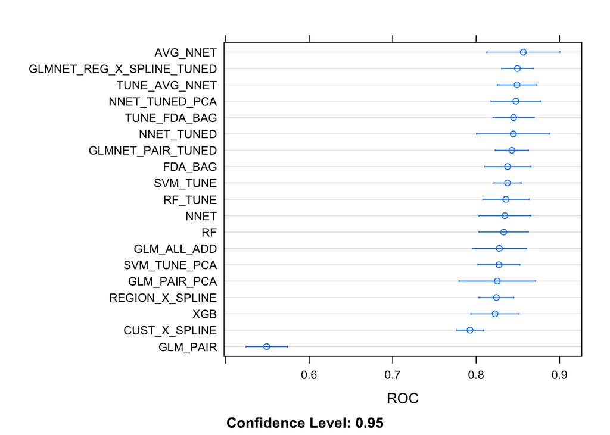

```r
all_cv_summary <- resamples(list(GLM_ALL_ADD = fit_glm_all_add,
                                  GLM_PAIR = fit_glm_cont_pairswise,
                                  GLM_PAIR_PCA = fit_glm_cont_pairswise_pca,
                                  REGION_X_SPLINE = fit_glm_region_X_spline,
                                  CUST_X_SPLINE = fit_glm_cust_X_spline,
                                  GLMNET_PAIR_TUNED = tuned_glmnet_outcome_pairwise_cat_add,
                                  GLMNET_REG_X_SPLINE_TUNED = tune_glmnet_region_X_spline,
                                  NNET = fit_nnet,
                                  NNET_TUNED = re_tune_nnet,
                                  NNET_TUNED_PCA = re_tune_nnet_pca,
                                  RF = fit_rf,
                                  RF_TUNE = re_tune_rf,
                                  XGB = re_fit_xgb,
                                  SVM_TUNE = re_tune_svm_radial,
                                  SVM_TUNE_PCA = re_tune_svm_radial_pca,
                                  FDA_BAG = fit_bag_fda,
                                  TUNE_FDA_BAG = re_tune_bag_fda,
                                  AVG_NNET = re_model_avg_nnet,
                                  TUNE_AVG_NNET = re_tune_avg_nnet
                                 ))


dotplot(all_cv_summary, metric = 'ROC')
```